# HW 2: Generalized Linear Models

Advanced Regression (STAT 353-0)

Author

Youran Chen

Published

January 29, 2026

**TipGithub Repo Link**

https://github.com/youranchen2027-source/stat353

## Handwork

Policy on handwork is that it is required for Statistics PhD students and MS in Statistics students. It is encouraged (but not required) for MS in Applied Statistics and all other students. If you are the latter, you will not get penalized if you get these wrong.

Exercises are from the course textbook *Applied Regression Analysis & Generaized Linear Models, 3rd Edtion (FOX)* — 14.1, 14.3, 14.6, 15.2, and 15.4.

You can type your answers directly into this document or you can do the work for each exercise on paper, take a picture of your solution, and include the image within this document (work must be legible).

Alternatively, you can do the Handwork exercises on paper and submit a scanned copy along with your html completing the Data Analysis exercises. That is, you will be submitting a pdf with your solution to the Handwork exercises and an html file with solutions to the Data Analysis exercises. Both documents should be well organized and in the case of the handwork, it must be legible.

**TipSolution**

The solution to the Handwork exercises is included in the pdf.

## Data analysis

### Exercise D14.1 (Dichotomous)

For this question, we will use the `Chile.txt` dataset, which has a polytomous outcome: voting intention (yes, no, abstain, undecided). For this problem, focus only on the subset of the data with outcomes of either ‘yes’ or ‘no’.

1. Formulate a model that makes substantive sense in the context of the data set - for example,constructing dummy regressors to represent factors and including interaction regressors where these are appropriate - and fit a linear logistic regression of the response variable on the explanatory variables, reporting the estimated regression coefficients and their asymptotic standard errors.

**TipSolution**

```r
chile <- read.table("Chile.txt", header = TRUE, sep = "", stringsAsFactors = FALSE)
data <- subset(chile, vote %in% c("Y", "N"))
data <- na.omit(data)

data$vote_binary <- ifelse(data$vote == "Y", 1, 0)
data$sex <- as.factor(data$sex)
data$education <- as.factor(data$education)

model <- glm(vote_binary ~ statusquo + population + sex + education + income + education * income,
             data = data,
             family = binomial(link = "logit"))

results <- summary(model)
print(results)
```

```
Call:
glm(formula = vote_binary ~ statusquo + population + sex + education +
    income + education * income, family = binomial(link = "logit"),
    data = data)

Coefficients:
                     Estimate Std. Error z value Pr(>|z|)
(Intercept)         6.591e-01  2.867e-01   2.299  0.02150 *
statusquo           3.241e+00  1.525e-01  21.249  < 2e-16 ***
population          6.585e-07  1.036e-06   0.636  0.52490
sexM               -5.898e-01  2.046e-01  -2.882  0.00395 **
educationPS        -9.447e-01  4.705e-01  -2.008  0.04464 *
educationS         -1.553e-02  3.237e-01  -0.048  0.96173
income              1.637e-05  9.838e-06   1.664  0.09608 .
educationPS:income -1.523e-05  1.070e-05  -1.423  0.15479
educationS:income  -2.716e-05  1.077e-05  -2.522  0.01168 *
---
Signif. codes:  0 '***' 0.001 '**' 0.01 '*' 0.05 '.' 0.1 ' ' 1

(Dispersion parameter for binomial family taken to be 1)

    Null deviance: 2360.29  on 1702  degrees of freedom
Residual deviance:  698.76  on 1694  degrees of freedom
AIC: 716.76

Number of Fisher Scoring iterations: 6
```

The estimated regression coefficients are shown in the “Estimate” column and the asymptotic standard errors are shown in the “Std. Error” column.

2. Construct an analysis-of-deviance table for the model fit in part (a).

**TipSolution**

```r
anova <- anova(model, test = "Chisq")
print(anova)
```

```
Analysis of Deviance Table

Model: binomial, link: logit

Response: vote_binary

Terms added sequentially (first to last)

                 Df Deviance Resid. Df Resid. Dev  Pr(>Chi)
NULL                              1702    2360.29
statusquo         1  1623.03      1701     737.27 < 2.2e-16 ***
population        1     0.01      1700     737.26 0.9288469
sex               1    11.34      1699     725.92 0.0007581 ***
education         2    17.84      1697     708.08 0.0001335 ***
income            1     0.85      1696     707.22 0.3555605
education:income  2     8.47      1694     698.76 0.0145145 *
---
Signif. codes:  0 '***' 0.001 '**' 0.01 '*' 0.05 '.' 0.1 ' ' 1
```

3. Fit a final model to the data that includes the statistically significant effects. Construct an effect display for each high-order term in the model, if your model includes them. If the model is additive, (i) suggest two interpretations of each estimated coefficient; and (ii) construct likelihood-ratio-based 95- percent confidence intervals for the regression coefficients, comparing these with confidence intervals based on the Wald statistic.

**TipSolution**

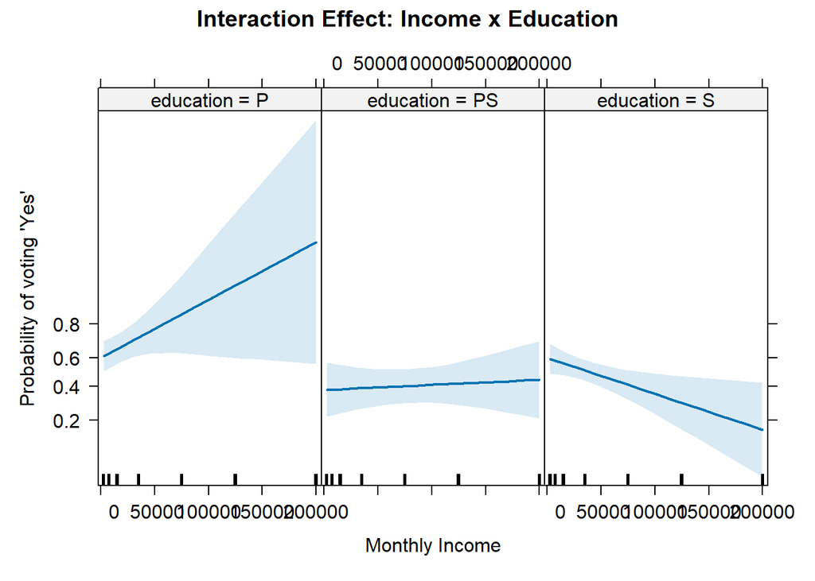

```r
library(effects)
final_model <- glm(vote_binary ~ statusquo + sex + education + education * income,
                   data = data,
                   family = binomial(link = "logit"))

eff_incedu <- effect("education:income", final_model)
plot(eff_incedu, main="Interaction Effect: Income x Education",
     xlab="Monthly Income", ylab="Probability of voting 'Yes'")
```

4. Fit a probit model to the data, comparing the results to those obtained with the logit model. Which do you think is better? Why?

**TipSolution**

```r
logit_model <- glm(vote_binary ~ statusquo + sex + education + education * income,
                   data = data,
                   family = binomial(link = "logit"))

probit_model <- glm(vote_binary ~ statusquo + sex + education + education * income,
                    data = data,
                    family = binomial(link = "probit"))

cat("Logit AIC:", AIC(logit_model), "\n")
```

```
Logit AIC: 715.1633
```

```r
cat("Probit AIC:", AIC(probit_model), "\n")
```

```
Probit AIC: 716.2044
```

```r
cat("Logit Log-Likelihood:", logLik(logit_model), "\n")
```

```
Logit Log-Likelihood: -349.5817
```

```r
cat("Probit Log-Likelihood:", logLik(probit_model), "\n")
```

```
Probit Log-Likelihood: -350.1022
```

The logit model is slightly better than the probit model. The logit model has a lower AIC and a higher log-likelihood, indicating that the logit model achieves a better balance between the model’s fitting degree and simplicity, and has a better fitting effect.

### Exercise D14.2 (Polytomous outcome)

Proceed as in Exercise D14.1, but now include all of the data and the four possible outcome values.

Use, as appropriate, one or more of the following: a multinomial logit model; a proportional odds logit model; logit models fit to a set of nested dichotomies; or similar probit models. If you fit the proportional-odds model, test the assumption of parallel regressions. If you fit more than one kind of model, which model do you prefer and why? If you only fit one model, why? Make sure to explain the results and interpretations of the preferred model.

**TipSolution**

This report applys a multinomial logit model. Since the outcome variable “vote” does not possess ordinality and hierarchy, it does not meet the prerequisites for using a proportional odds logit model or logit models tailored to a set of nested dichotomies. Additionally, compared to probit models, logit models offer better fitting results and greater stability.

```r
library(car)
library(nnet)

data2 <- na.omit(chile)
data2$vote <- as.factor(data2$vote)
data2$vote <- relevel(data2$vote, ref = "N")
data2$sex <- as.factor(data2$sex)
data2$education <- as.factor(data2$education)
data2$region <- as.factor(data2$region)

multi_model <- multinom(vote ~ statusquo + sex + population + education + income + age + region + income * statusquo, data = data2)
summary_multi <- summary(multi_model)
print(summary_multi)
```

```
Call:
multinom(formula = vote ~ statusquo + sex + population + education +
    income + age + region + income * statusquo, data = data2)

Coefficients:
  (Intercept) statusquo       sexM    population educationPS educationS
A   0.3754540  1.901212 -0.6883126 -3.280060e-07  -0.1939240  0.2651781
U   1.1694073  2.153144 -0.9311678 -1.036966e-06  -1.0597927 -0.3414220
Y   0.6430615  3.477931 -0.7747568 -9.270456e-07  -0.7285531 -0.4091157
         income          age    regionM    regionN     regionS  regionSA
A -3.753437e-06 -0.009652253 -0.9319900  0.3456244 -0.41124077 0.1353344
U -6.645030e-06  0.016027749  0.1143033 -0.2793967 -0.29706494 0.5176361
Y -5.903576e-06  0.010650123  0.3942269  0.4632282  0.03185393 0.5803143
  statusquo:income
A    -1.298794e-06
U     1.260116e-06
Y     8.514592e-06

Std. Errors:
   (Intercept)    statusquo         sexM   population  educationPS   educationS
A 3.767696e-08 8.360065e-07 5.615741e-08 6.071269e-07 6.169631e-09 8.686540e-08
U 2.154501e-05 9.327802e-06 9.789102e-06 4.980170e-07 9.252070e-07 2.206854e-06
Y 1.830603e-05 1.344432e-05 8.286964e-06 5.901707e-07 7.707627e-07 2.116390e-06
        income          age      regionM      regionN      regionS     regionSA
A 2.616271e-06 8.293520e-06 6.896962e-09 3.363751e-08 4.645200e-08 4.014590e-08
U 2.260050e-06 1.261172e-03 1.610387e-06 3.202833e-06 1.107404e-05 2.763327e-06
Y 2.696421e-06 1.044027e-03 1.343709e-06 2.828871e-06 9.746755e-06 2.183644e-06
  statusquo:income
A     2.680177e-06
U     2.430586e-06
Y     3.209760e-06

Residual Deviance: 3992.898
AIC: 4070.898
```

```r
multi_anova <- Anova(multi_model, type = "II", test = "Chisq")
print(multi_anova)
```

```
Analysis of Deviance Table (Type II tests)

Response: vote
                 LR Chisq Df Pr(>Chisq)
statusquo         1782.31  3  < 2.2e-16 ***
sex                 49.24  3  1.161e-10 ***
population           1.17  3  0.7596924
education           28.26  6  8.405e-05 ***
income              16.58  3  0.0008602 ***
age                 17.82  3  0.0004786 ***
region              32.61 12  0.0011116 **
statusquo:income     8.00  3  0.0461144 *
---
Signif. codes:  0 '***' 0.001 '**' 0.01 '*' 0.05 '.' 0.1 ' ' 1
```

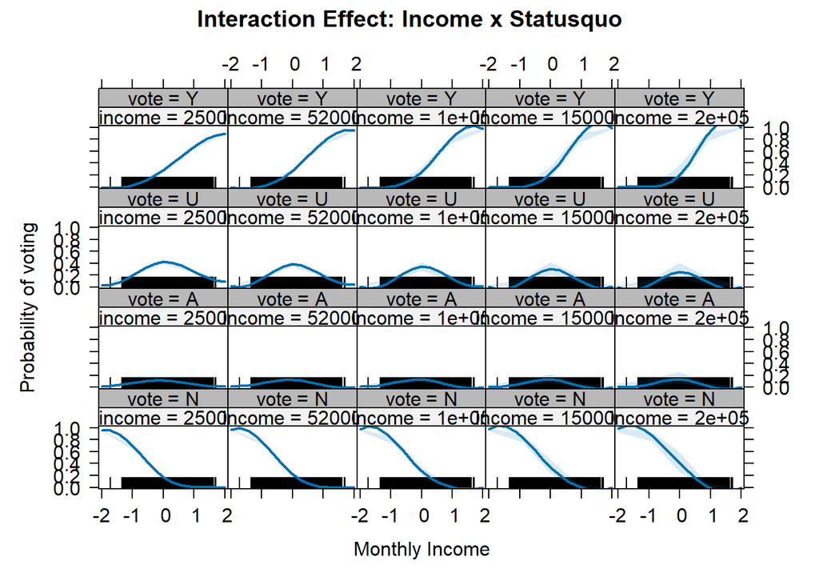

```r
library(effects)
final_multi_model <- multinom(vote ~ statusquo + sex + education + income + age + region + income * statusquo, data = data2)
eff_incsta <- effect("statusquo:income", final_multi_model)
plot(eff_incsta, main="Interaction Effect: Income x Statusquo",
     xlab="Monthly Income", ylab="Probability of voting")
```

```r
library(MNP)

logit_multi <- multinom(vote ~ statusquo + sex + education + income + age + region + income * statusquo, data = data2)
probit_multi <- mnp(vote ~ statusquo + sex + education + income + age + region + income * statusquo,
                    data = data2, base = "N")

actual_matrix <- model.matrix(~ vote - 1, data = data2)
prob_logit <- predict(logit_multi, type = "probs")
pred_probit_obj <- predict(probit_multi, newdata = data2)
prob_probit <- pred_probit_obj$p
mae_logit <- mean(abs(prob_logit - actual_matrix))
mae_probit <- mean(abs(prob_probit - actual_matrix))

cat("Logit MAE:", mae_logit, "\n")
```

```
Logit MAE: 0.2210315
```

```r
cat("Probit MAE:", mae_probit, "\n")
```

```
Probit MAE: 0.2289346
```

The logit model has a lower MAE, indicating that the logit model has a better fitting effect than the probit model.

### Exercise D15.3 (GLM Diagnostics)

Return to the logit (and probit) model that you fit in Exercise D14.1.

1. Use the diagnostic methods for generalized linear models described in this chapter to check the adequacy of the final model that you fit to the data.

**TipSolution**

```r
library(ResourceSelection)
hoslem.test(data$vote_binary, fitted(logit_model))
```

```
    Hosmer and Lemeshow goodness of fit (GOF) test

data:  data$vote_binary, fitted(logit_model)
X-squared = 15.857, df = 8, p-value = 0.04448
```

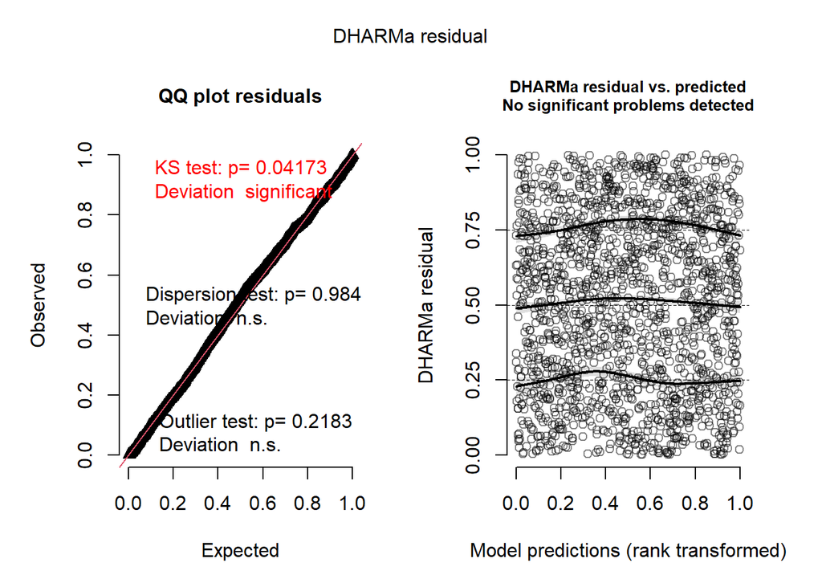

```r
library(DHARMa)
simulationOutput <- simulateResiduals(fittedModel = logit_model)
plot(simulationOutput)
```

2. If the model contains a discrete quantitative explanatory variable (such as a binned variable), test for nonlinearity by specifying a model that treats this variable as a factor (e.g., using dummy regressors), and comparing that model via a likelihood-ratio test to the model that specifies that the variable has a linear effect. (If there is more than one discrete quantitative explanatory variable, then begin with a model that treats all of them as factors, contrasting this with a sequence of models that specifies a linear effect for each such variable in turn.) Note that this is analogous to the approach for testing for nonlinearity in a linear model with discrete explanatory variables described in Section 12.4.1.

**TipSolution**

```r
chile <- read.table("Chile.txt", header = TRUE, sep = "", stringsAsFactors = FALSE)
data3 <- subset(chile, vote %in% c("Y", "N"))
data3 <- na.omit(data3)
data3$vote_binary <- ifelse(data3$vote == "Y", 1, 0)

logit <- glm(vote_binary ~ statusquo + sex + education + education * income,
                    data = data3, family = binomial(link = "logit"))

fac_inc <- glm(vote_binary ~ statusquo + sex + education + education * as.factor(income),
                    data = data3, family = binomial(link = "logit"))
anova(logit, fac_inc, test = "Chisq")
```

```
Analysis of Deviance Table

Model 1: vote_binary ~ statusquo + sex + education + education * income
Model 2: vote_binary ~ statusquo + sex + education + education * as.factor(income)
  Resid. Df Resid. Dev Df Deviance Pr(>Chi)
1      1695     699.16
2      1680     687.19 15   11.973   0.6811
```

Since p > 0.05, we cannot reject the null hypothesis that “income has a linear effect on vote”.

3. Explore the use of the Cauchy and complementary-log-log links as alternatives to the logit link for this regression. Comparing deviances under the different links, which link appears to best represent the data?

**TipSolution**

```r
fit_logit <- glm(vote_binary ~ statusquo + sex + education + education * income, data = data, family = binomial(link = "logit"))
fit_cauchit <- glm(vote_binary ~ statusquo + sex + education + education * income, data = data, family = binomial(link = "cauchit"))
fit_cloglog <- glm(vote_binary ~ statusquo + sex + education + education * income, data = data, family = binomial(link = "cloglog"))

models <- list(Logit = fit_logit, Cauchit = fit_cauchit, Cloglog = fit_cloglog)

model_comparison <- data.frame(
  Model = names(models),
  Deviance = sapply(models, deviance),
  AIC = sapply(models, AIC),
  BIC = sapply(models, BIC)
)

print(model_comparison)
```

```
          Model Deviance      AIC      BIC
Logit     Logit 699.1633 715.1633 758.6845
Cauchit Cauchit 733.8934 749.8934 793.4145
Cloglog Cloglog 760.8001 776.8001 820.3213
```

The logit model has the lowest deviance, AIC and BIC, which best represents the data

### Exercise D15.1 (Count data)

Long (1990, 1997) investigates factors affecting the research productivity of doctoral students in biochemistry. Long’s data (on 915 biochemists) are in the file `Long.txt`. The response variable in this investigation, `art`, is the number of articles published by the student during the last three years of his or her PhD programme. Overview of the explanatory variables are provided in Table 1 below.

Table 1: Explanatory variables in `long.txt` data

| Variable name | Definition |
| --- | --- |
| `fem` | Gender: dummy variable - 1 if female, 0 if male |
| `mar` | Maritial status: dummy variable - 1 if married, 0 if not |
| `kid5` | Number of children five years old or younger |
| `phd` | Prestige rating of PhD department |
| `ment` | Number of articles published by mentor during last three years |

1. Examine the distribution of the response variable. Based on this distribution, does it appear promising to model these data by linear least-squares regression, perhaps after transforming the response? Explain your answer.

**TipSolution**

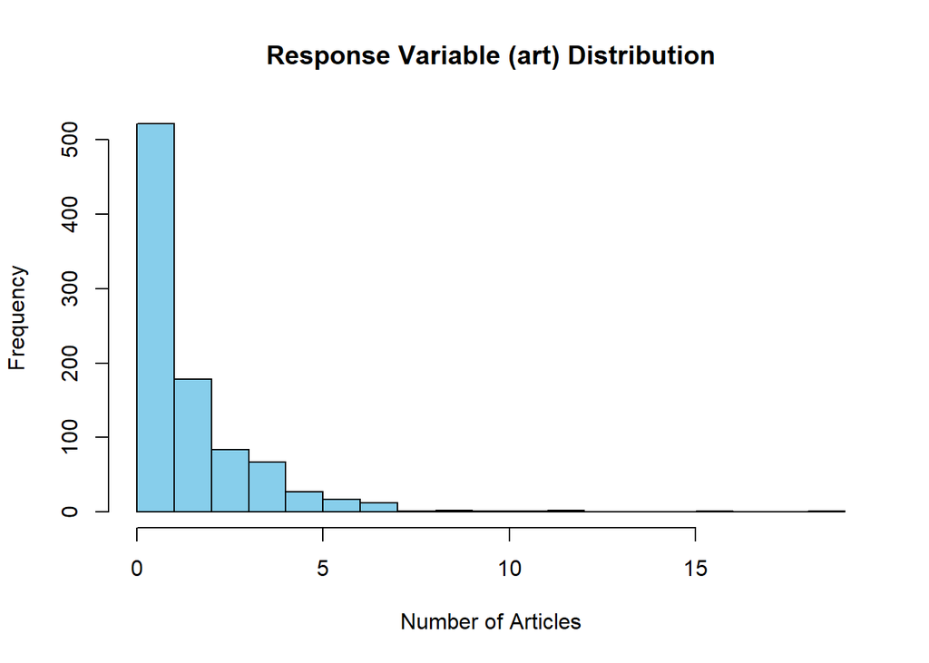

```r
long <- read.table("Long.txt", header = TRUE, sep = "", stringsAsFactors = FALSE)
hist(long$art, breaks = 20, main = "Response Variable (art) Distribution", xlab = "Number of Articles", col = "skyblue")
```

I think it is not promising to model these data using linear least-squares regression. The data of the outcome variable ‘art’ is concentrated around 0, which does not meet the assumption of normality.

2. Following Long, perform a Poisson regression of art on the explanatory variables. What do you conclude from the results of this regression? Be sure to interpret the results.

**TipSolution**

```r
poisson_model <- glm(art ~ fem + mar + kid5 + phd + ment,
                     family = poisson(link = "log"),
                     data = long)
summary(poisson_model)
```

```
Call:
glm(formula = art ~ fem + mar + kid5 + phd + ment, family = poisson(link = "log"),
    data = long)

Coefficients:
             Estimate Std. Error z value Pr(>|z|)
(Intercept)  0.304619   0.102980   2.958   0.0031 **
fem         -0.224594   0.054613  -4.112 3.92e-05 ***
mar          0.155243   0.061374   2.529   0.0114 *
kid5        -0.184883   0.040127  -4.607 4.08e-06 ***
phd          0.012822   0.026397   0.486   0.6271
ment         0.025543   0.002006  12.733  < 2e-16 ***
---
Signif. codes:  0 '***' 0.001 '**' 0.01 '*' 0.05 '.' 0.1 ' ' 1

(Dispersion parameter for poisson family taken to be 1)

    Null deviance: 1817.4  on 914  degrees of freedom
Residual deviance: 1634.4  on 909  degrees of freedom
AIC: 3314.1

Number of Fisher Scoring iterations: 5
```

The coefficient for the “fem” factor is negative, at -0.224594. The projected publication volume for women is approximately $e^{-0.2} \approx 0.82$ times that of men (which is a decrease of 18%). The p-value is 3.92e-05, indicating that this variable has a significant impact on the response variable.

The coefficient for the “mar” factor is positive, at 0.155243. The expected publication rate for married individuals is approximately $e^{0.16} \approx 1.17$ times that of unmarried individuals. The p-value is 0.0114, indicating that this variable has a impact on the response variable.

3. Perform regression diagnostics on the model fit in the previous question. If you identify any problems, try to deal with them. Are the conclusions of the research altered?

**TipSolution**

```r
library(AER)
dispersiontest(poisson_model)
```

```
    Overdispersion test

data:  poisson_model
z = 5.7825, p-value = 3.681e-09
alternative hypothesis: true dispersion is greater than 1
sample estimates:
dispersion
   1.82454
```

```r
library(MASS)
nb_model <- glm.nb(art ~ fem + mar + kid5 + phd + ment, data = long)
summary(nb_model)
```

```
Call:
glm.nb(formula = art ~ fem + mar + kid5 + phd + ment, data = long,
    init.theta = 2.264387444, link = log)

Coefficients:
             Estimate Std. Error z value Pr(>|z|)
(Intercept)  0.256143   0.137345   1.865 0.062188 .
fem         -0.216418   0.072636  -2.979 0.002887 **
mar          0.150490   0.082097   1.833 0.066790 .
kid5        -0.176415   0.052813  -3.340 0.000837 ***
phd          0.015272   0.035872   0.426 0.670313
ment         0.029082   0.003214   9.048  < 2e-16 ***
---
Signif. codes:  0 '***' 0.001 '**' 0.01 '*' 0.05 '.' 0.1 ' ' 1

(Dispersion parameter for Negative Binomial(2.2644) family taken to be 1)

    Null deviance: 1109.0  on 914  degrees of freedom
Residual deviance: 1004.3  on 909  degrees of freedom
AIC: 3135.9

Number of Fisher Scoring iterations: 1

              Theta:  2.264
          Std. Err.:  0.271

 2 x log-likelihood:  -3121.917
```

In the dispersion test, the result is 1.82454, which is greater than 1, there is overdispersion. I try to use the Negative Binomial model, the impacts of fem and mar become lower.

4. Refit Long’s model allowing for overdispersion (using a quasi-Poisson or negative-binomial model). Does this make a difference to the results?

**TipSolution**

```r
library(MASS)
nb_model <- glm.nb(art ~ fem + mar + kid5 + phd + ment, data = long)
qp_model <- glm(art ~ fem + mar + kid5 + phd + ment,
                family = quasipoisson, data = long)

summary(nb_model)
```

```
Call:
glm.nb(formula = art ~ fem + mar + kid5 + phd + ment, data = long,
    init.theta = 2.264387444, link = log)

Coefficients:
             Estimate Std. Error z value Pr(>|z|)
(Intercept)  0.256143   0.137345   1.865 0.062188 .
fem         -0.216418   0.072636  -2.979 0.002887 **
mar          0.150490   0.082097   1.833 0.066790 .
kid5        -0.176415   0.052813  -3.340 0.000837 ***
phd          0.015272   0.035872   0.426 0.670313
ment         0.029082   0.003214   9.048  < 2e-16 ***
---
Signif. codes:  0 '***' 0.001 '**' 0.01 '*' 0.05 '.' 0.1 ' ' 1

(Dispersion parameter for Negative Binomial(2.2644) family taken to be 1)

    Null deviance: 1109.0  on 914  degrees of freedom
Residual deviance: 1004.3  on 909  degrees of freedom
AIC: 3135.9

Number of Fisher Scoring iterations: 1

              Theta:  2.264
          Std. Err.:  0.271

 2 x log-likelihood:  -3121.917
```

```r
summary(qp_model)
```

```
Call:
glm(formula = art ~ fem + mar + kid5 + phd + ment, family = quasipoisson,
    data = long)

Coefficients:
             Estimate Std. Error t value Pr(>|t|)
(Intercept)  0.304619   0.139271   2.187 0.028979 *
fem         -0.224594   0.073860  -3.041 0.002427 **
mar          0.155243   0.083003   1.870 0.061759 .
kid5        -0.184883   0.054268  -3.407 0.000686 ***
phd          0.012822   0.035699   0.359 0.719552
ment         0.025543   0.002713   9.415  < 2e-16 ***
---
Signif. codes:  0 '***' 0.001 '**' 0.01 '*' 0.05 '.' 0.1 ' ' 1

(Dispersion parameter for quasipoisson family taken to be 1.829006)

    Null deviance: 1817.4  on 914  degrees of freedom
Residual deviance: 1634.4  on 909  degrees of freedom
AIC: NA

Number of Fisher Scoring iterations: 5
```